# Single and Multiple Regression

Ethan Tenison

2/4/2020

# Q1: Interactioneffects in a linear regression

### (a)Write an equation to specify a linear regression model for this problem. You will need to create/define variables.What is the unit of analysis?

$\hat{y}$ = $\beta_{0}$ + $\beta_{s}$$X_{s}$ + $\beta_{m}$$X_{m}$ + $\varepsilon$

$\hat{y}$ = the estimated property value  
$\beta_{0}$ = intercept  
$\beta_{s}$ = coefficient for single-family home  
$X_{s}$ = dummy variable that is 1 for single-family and 0 for not  
$\beta_{m}$ = coefficient for multi-unit home  
$X_{m}$ = dummy variable that is 1 for multi-unit and 0 for not  
$\varepsilon$ = the error term  
The unit of analysis is property value of the neighborhood

### (b)Interpret the coefficients in the equation from (a).

The coefficients represent, all things being equal, how much being a permitted single-family and/or multi-unit neighborhood has on property value. The $\beta_{0}$ represents the intercept when a neighborhood is neither permitted to be a single-family or multi-unit area. $\beta_{s}$ is the coefficient for the dummy variable for single-family neighborhood. $\beta_{m}$ is the coefficient for the dummy variable for multi-unit neighborhood. $\varepsilon$ is the disturbance term that contains all of the reducivle and irreducivle error.

### (c)For all of the possible combinations of “states” of predictor variables, give estimates for property values.

Single-Family only: $\hat{y}$ = $\beta_{0}$ + $\beta_{s}$$(1)$ + $\beta_{m}$$(0)$ +$\varepsilon$
Multi-unit only: $\hat{y}$ = $\beta_{0}$ + $\beta_{s}$$(0)$ + $\beta_{m}$$(1)$ +$\varepsilon$
Both: $\hat{y}$ = $\beta_{0}$ + $\beta_{s}$$(1)$ + $\beta_{m}$$(1)$ +$\varepsilon$

### (d)What is the expected difference between single-family YES multi-unit NO neighborhood and a single-family YES multi-unit YES neighborhood?

($\beta_{0}$ + $\beta_{s}$$(1)$ + $\beta_{m}$$(1)$ +$\varepsilon$) - ($\beta_{0}$ + $\beta_{s}$$(1)$ + $\beta_{m}$$(0)$ +$\varepsilon$)
= $\beta_{m}$$(1)$

### (e)Does allowing multi-unit housing in single-family neighborhoods cause property values to change? Why or why not?

It depends on the coefficient. Is it statistically different from zero or not? If it is, than adding multi-unit housing to a single-family neighborhood could (on average) increase or decrease property value.

### (f)To provide the best possible information to the council, what might you –as an analyst –need? What might ruin your findings?

In order to construct a good model I would need data on all the relevant predictors of property value. For example, the existence of a park in the neighborhood might have an impact. The findings might be ruined if the model leaves out some important predictor variable like the location of the neighborhood within the city. Neighborhoods in Mt.Bonnel are going to have a higher property value than on Rundberg regardless of whether it’s a single-family or multi-unit neighborhood. There may also be a problem with your results if the there is interaction between the two. Other potential problems are multicolinearity, observations with high-leverage, outliers, non-constant variance of the error terms, correlation of the error terms, and non-linearity.

# Q2: Applying Multiple Linear Regressionto data.

### (a)Produce a scatterplot matrix which includes the variables SalePrice, GarageCars, Age, OverallQual, and OverallCond.Circle any relationship that appears to be non-linear.

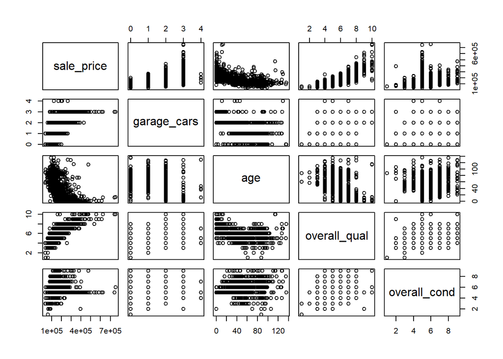

```r
library(dplyr)
library(janitor)

df <- read.csv("austin_house_price.csv")
df <- clean_names(df)
a <- select(df, sale_price, garage_cars, age, overall_qual, overall_cond)
pairs(a, )
```

### (b)Compute the matrix of correlations between the variablesSalePrice, GarageCars, Age, OverallQual, and OverallCond. Between which 2 variables is the highest correlation?

The two variables with the highest correlation are overall_qual and sale_price at 0.79098160

```r
b = cor(a)
b
```

```
##               sale_price garage_cars        age overall_qual overall_cond
## sale_price    1.00000000   0.6404092 -0.5233504   0.79098160  -0.07785589
## garage_cars   0.64040920   1.0000000 -0.5387274   0.60067072  -0.18575751
## age          -0.52335042  -0.5387274  1.0000000  -0.57262947   0.37732550
## overall_qual  0.79098160   0.6006707 -0.5726295   1.00000000  -0.09193234
## overall_cond -0.07785589  -0.1857575  0.3773255  -0.09193234   1.00000000
```

### (c) Perform a multiple linear regression with SalePrice as the response and other variables as the predictors. Use as many variables as you need to improve the model and justify your decision. Is there a relationship between the predictors and the response? What does the coefficient for the age variable suggest?

I included all of the variables except tot_rms_abv_grd because that would have double counted rooms. All of them were significant at the 95% level except for age and bsmt_half_bath. The p-value for age was higher than .2, which tells us that we can’t rule out the possibility that age has zero impact on property value. Additionally, removing age from the model only changes the adj r squared by .0001

```r
c = lm(sale_price ~ garage_cars + age + overall_qual + overall_cond + bsmt_full_bath + bsmt_half_bath + full_bath + half_bath + bedroom_abv_gr + kitchen_abv_gr + fireplaces, data=df)
summary(c)
```

```
##
## Call:
## lm(formula = sale_price ~ garage_cars + age + overall_qual +
##     overall_cond + bsmt_full_bath + bsmt_half_bath + full_bath +
##     half_bath + bedroom_abv_gr + kitchen_abv_gr + fireplaces,
##     data = df)
##
## Residuals:
##     Min      1Q  Median      3Q     Max
## -225278  -23461   -3314   17981  372246
##
## Coefficients:
##                  Estimate Std. Error t value Pr(>|t|)
## (Intercept)    -103513.86   10737.45  -9.640  < 2e-16 ***
## garage_cars      20731.90    1953.82  10.611  < 2e-16 ***
## age                -67.49      54.70  -1.234 0.217472
## overall_qual     27741.80    1209.58  22.935  < 2e-16 ***
## overall_cond      3671.20    1093.38   3.358 0.000806 ***
## bsmt_full_bath   22751.19    2249.55  10.114  < 2e-16 ***
## bsmt_half_bath    8468.93    4679.01   1.810 0.070506 .
## full_bath        23003.84    2882.90   7.979 2.97e-15 ***
## half_bath         7733.35    2385.62   3.242 0.001215 **
## bedroom_abv_gr    4611.60    1568.74   2.940 0.003337 **
## kitchen_abv_gr  -11418.49    5437.35  -2.100 0.035901 *
## fireplaces       16631.44    1914.19   8.688  < 2e-16 ***
## ---
## Signif. codes:  0 '***' 0.001 '**' 0.01 '*' 0.05 '.' 0.1 ' ' 1
##
## Residual standard error: 41570 on 1448 degrees of freedom
## Multiple R-squared:  0.7283, Adjusted R-squared:  0.7262
## F-statistic: 352.9 on 11 and 1448 DF,  p-value: < 2.2e-16
```

### (d) Include the variable Age as a predictor in your model. Try a few different transformations of the Age variable, such as log(X), √X, X2. Comment on your findings.

```r
d = df
d = filter(d, age != 0)
d = lm(sale_price ~ garage_cars + log(age) + overall_qual + overall_cond + bsmt_full_bath + bsmt_half_bath + full_bath + half_bath + bedroom_abv_gr + kitchen_abv_gr + fireplaces, data=d,)
print(summary(d))
```

```
##
## Call:
## lm(formula = sale_price ~ garage_cars + log(age) + overall_qual +
##     overall_cond + bsmt_full_bath + bsmt_half_bath + full_bath +
##     half_bath + bedroom_abv_gr + kitchen_abv_gr + fireplaces,
##     data = d)
##
## Residuals:
##     Min      1Q  Median      3Q     Max
## -124177  -22422   -2938   17765  381378
##
## Coefficients:
##                Estimate Std. Error t value Pr(>|t|)
## (Intercept)      -86519      11351  -7.622 4.60e-14 ***
## garage_cars       18176       1930   9.418  < 2e-16 ***
## log(age)          -4871       1295  -3.761 0.000176 ***
## overall_qual      25125       1272  19.751  < 2e-16 ***
## overall_cond       5069       1061   4.776 1.98e-06 ***
## bsmt_full_bath    23856       2175  10.967  < 2e-16 ***
## bsmt_half_bath     8071       4526   1.783 0.074781 .
## full_bath         22477       2818   7.975 3.18e-15 ***
## half_bath          7915       2314   3.421 0.000643 ***
## bedroom_abv_gr     6241       1557   4.007 6.48e-05 ***
## kitchen_abv_gr   -10401       5210  -1.996 0.046076 *
## fireplaces        19235       1903  10.110  < 2e-16 ***
## ---
## Signif. codes:  0 '***' 0.001 '**' 0.01 '*' 0.05 '.' 0.1 ' ' 1
##
## Residual standard error: 40030 on 1384 degrees of freedom
## Multiple R-squared:  0.733,  Adjusted R-squared:  0.7309
## F-statistic: 345.4 on 11 and 1384 DF,  p-value: < 2.2e-16
```

```r
dd = df
dd = filter(dd, age != 0)
dd = lm(sale_price ~ garage_cars + sqrt(age) + overall_qual + overall_cond + bsmt_full_bath + bsmt_half_bath + full_bath + half_bath + bedroom_abv_gr + kitchen_abv_gr + fireplaces, data=dd,)
print(summary(dd))
```

```
##
## Call:
## lm(formula = sale_price ~ garage_cars + sqrt(age) + overall_qual +
##     overall_cond + bsmt_full_bath + bsmt_half_bath + full_bath +
##     half_bath + bedroom_abv_gr + kitchen_abv_gr + fireplaces,
##     data = dd)
##
## Residuals:
##     Min      1Q  Median      3Q     Max
## -127859  -22881   -3434   17617  377054
##
## Coefficients:
##                Estimate Std. Error t value Pr(>|t|)
## (Intercept)    -96369.1    11075.2  -8.701  < 2e-16 ***
## garage_cars     18967.8     1939.2   9.781  < 2e-16 ***
## sqrt(age)       -1345.8      653.7  -2.059 0.039717 *
## overall_qual    26162.1     1249.1  20.944  < 2e-16 ***
## overall_cond     4498.6     1078.9   4.170 3.24e-05 ***
## bsmt_full_bath  23410.3     2205.6  10.614  < 2e-16 ***
## bsmt_half_bath   7565.3     4547.8   1.664 0.096438 .
## full_bath       23562.3     2872.5   8.203 5.31e-16 ***
## half_bath        7824.8     2349.7   3.330 0.000891 ***
## bedroom_abv_gr   5497.3     1564.4   3.514 0.000456 ***
## kitchen_abv_gr -11262.8     5264.8  -2.139 0.032588 *
## fireplaces      18424.4     1906.6   9.663  < 2e-16 ***
## ---
## Signif. codes:  0 '***' 0.001 '**' 0.01 '*' 0.05 '.' 0.1 ' ' 1
##
## Residual standard error: 40170 on 1384 degrees of freedom
## Multiple R-squared:  0.7311, Adjusted R-squared:  0.7289
## F-statistic:   342 on 11 and 1384 DF,  p-value: < 2.2e-16
```

# Q3. Simple Linear Regressionson simulated data.

### (a)Create a vector, x, containing 100 observations drawn from a N (0, 1) distribution. This represents a feature: X.

```r
set.seed(124)

x <- rnorm(100, 0, 1)
x
```

```
##   [1] -1.38507062  0.03832318 -0.76303016  0.21230614  1.42553797  0.74447982
##   [7]  0.70022940 -0.22935461  0.19709386  1.20715377  0.31833673 -1.42379885
##  [13] -0.40509086  0.99538657  0.95881779  0.91808790 -0.15096960 -1.22306879
##  [19] -0.86882429 -1.04248536 -1.10363778  0.44418506 -0.20495061  1.67563243
##  [25] -0.13132225 -0.19988298  0.05491242 -0.68216549 -0.72770415 -0.86190429
##  [31] -0.03752311 -1.63142324  0.17716660 -0.01250080 -0.39431713  0.35156293
##  [37]  0.87876756  0.20465408 -0.88738071 -0.47721606 -0.26774095  1.58585916
##  [43]  0.04690059  0.35649678 -0.12138001 -0.03609184 -0.98114749 -0.43425983
##  [49] -0.06748436  0.98189457 -0.46205239 -0.22509928 -0.84644780  0.07304632
##  [55] -0.27503642 -0.38642636 -0.04620314 -0.82589372 -0.85403424  0.11873681
##  [61]  0.28359691  1.93008647 -1.14052762 -1.32211824  1.22883161 -0.54845603
##  [67] -0.12600749  0.68771872  0.70520038  0.80147843 -0.46288318 -0.88455498
##  [73] -1.63092757  0.56223059 -0.32589183  0.24137562  1.08586910  1.90706161
##  [79]  0.81292745  0.49488879 -0.09514776  1.13878050  0.50231463 -0.51541405
##  [85] -2.46839047 -0.87255274  0.96408808  0.91079625  1.92580884 -0.30290695
##  [91] -1.05470705  0.41811609  0.70127282  0.24675828  0.46429516 -0.39546819
##  [97]  0.71307031  1.18501256 -1.91114929  1.11493056
```

### (b)Create another vector, eps, containing 100 observations drawn from a N(0,0.25) distribution i.e. a normal distribution with mean zero and variance 0.25

```r
eps <- rnorm(100, 0, 0.25)
eps
```

```
##   [1] -0.117325052 -0.287000688  0.275999489 -0.072312479 -0.069332155
##   [6] -0.218945660  0.000819788  0.066397906 -0.031006033 -0.032231476
##  [11]  0.074778079  0.004574803 -0.287515333 -0.107349087  0.212500744
##  [16] -0.053707373 -0.154353504  0.027356846 -0.176627766  0.385743954
##  [21]  0.087700430  0.293155144 -0.008343383  0.090360999  0.261393910
##  [26]  0.025803098  0.082948889 -0.392139704  0.110067486  0.470467831
##  [31]  0.337276566 -0.408770693 -0.178883183 -0.229123581 -0.590256736
##  [36]  0.382112500 -0.157446806 -0.267023005  0.311214956  0.114969037
##  [41]  0.041926457 -0.068750756  0.123080655  0.334938643 -0.119186056
##  [46] -0.374198884 -0.300355993 -0.101865257 -0.236937024  0.212916600
##  [51] -0.147107752 -0.340618276 -0.112409486 -0.160831258 -0.127686388
##  [56]  0.064300503 -0.104888862 -0.238056914  0.128098351 -0.436066921
##  [61] -0.124378103  0.191396445  0.125348267  0.082977793 -0.022768933
##  [66] -0.164170508 -0.290212035  0.413982983 -0.187302637  0.155480139
##  [71] -0.367951292  0.199548864  0.069865627  0.164468565  0.148431581
##  [76] -0.144481628  0.119015684 -0.296908405  0.179422011  0.033674311
##  [81]  0.355520085  0.010182728 -0.084602438 -0.139528847  0.256953371
##  [86] -0.056367620 -0.307907513 -0.189561185  0.271379537 -0.262274721
##  [91]  0.072599888 -0.111893357 -0.054715192 -0.401360878  0.018709921
##  [96] -0.130479675 -0.016225592  0.262842492 -0.435539566  0.433137007
```

### (c) Using x and eps, generate a vector y according to the model Y =−1+0.5X+ε. What is the length of the vector y? What are the values of β0 and β1 in this linear model?

The length of the vector y is 100. β0 is equal to -1 and β1 is equal to 0.5

```r
y <- (-1 + 0.5*x + eps)
y
```

```
##   [1] -1.809860361 -1.267839098 -1.105515592 -0.966159411 -0.356563172
##   [6] -0.846705749 -0.649065511 -1.048279400 -0.932459102 -0.428654589
##  [11] -0.766053558 -1.707324624 -1.490060762 -0.609655804 -0.308090362
##  [16] -0.594663425 -1.229838305 -1.584177548 -1.611039910 -1.135498728
##  [21] -1.464118461 -0.484752326 -1.110818689 -0.071822785 -0.804267215
##  [26] -1.074138391 -0.889594903 -1.733222448 -1.253784588 -0.960484312
##  [31] -0.681484991 -2.224482313 -1.090299885 -1.235373980 -1.787415299
##  [36] -0.442106034 -0.718063025 -1.164695965 -1.132475399 -1.123638993
##  [41] -1.091944020 -0.275821174 -0.853469048 -0.486812969 -1.179876059
##  [46] -1.392244805 -1.790929736 -1.318995171 -1.270679201 -0.296136117
##  [51] -1.378133948 -1.453167917 -1.535633386 -1.124308098 -1.265204598
##  [56] -1.128912676 -1.127990433 -1.651003775 -1.298918768 -1.376698517
##  [61] -0.982579650  0.156439678 -1.444915542 -1.578081329 -0.408353131
##  [66] -1.438398524 -1.353215781 -0.242157656 -0.834702449 -0.443780647
##  [71] -1.599392882 -1.242728628 -1.745598159 -0.554416141 -1.014514336
##  [76] -1.023793818 -0.338049767 -0.343377597 -0.414114264 -0.718881295
##  [81] -0.692053797 -0.420427022 -0.833445123 -1.397235874 -1.977241863
##  [86] -1.492643992 -0.825863473 -0.734163061  0.234283956 -1.413728195
##  [91] -1.454753637 -0.902835314 -0.704078781 -1.277981737 -0.749142498
##  [96] -1.328213769 -0.659690440 -0.144651230 -2.391114210 -0.009397711
```

### (d)Create a scatterplot displaying the relationship between x and y. Comment on what you observe.

X appears to be strongly correlated with y.

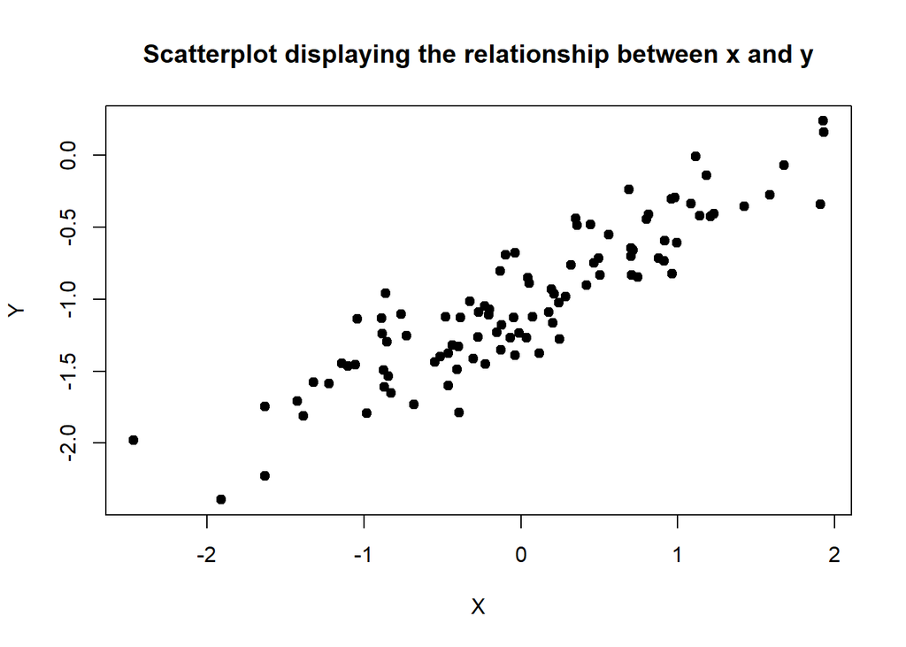

```r
plot(x, y, main="Scatterplot displaying the relationship between x and y",
   xlab="X", ylab="Y", pch=19)
```

### (e)Fit a least squares linear model to predict y using x. Comment on the model obtained. How do βˆ0 and βˆ1 compare to β0 and β1?

```r
df <- data.frame(x,y)

model <- lm(y~x, data = df)
summary(model)
```

```
##
## Call:
## lm(formula = y ~ x, data = df)
##
## Residuals:
##      Min       1Q   Median       3Q      Max
## -0.55638 -0.14227 -0.01977  0.15411  0.51564
##
## Coefficients:
##             Estimate Std. Error t value Pr(>|t|)
## (Intercept) -1.02435    0.02264  -45.25   <2e-16 ***
## x            0.52416    0.02574   20.36   <2e-16 ***
## ---
## Signif. codes:  0 '***' 0.001 '**' 0.01 '*' 0.05 '.' 0.1 ' ' 1
##
## Residual standard error: 0.2264 on 98 degrees of freedom
## Multiple R-squared:  0.8088, Adjusted R-squared:  0.8069
## F-statistic: 414.7 on 1 and 98 DF,  p-value: < 2.2e-16
```

### (f) Now fit a polynomial regression model that predicts y using x and x2. Is there evidence that the quadratic term improves the model fit? Explain your answer.

Adding a quadratic to this model only increases the r squared slightly. This might be because x and y already have a strong correlation.

```r
model <- lm(y ~ poly(x,2), data = df)
summary(model)
```

```
##
## Call:
## lm(formula = y ~ poly(x, 2), data = df)
##
## Residuals:
##      Min       1Q   Median       3Q      Max
## -0.53870 -0.13423 -0.02134  0.16343  0.51723
##
## Coefficients:
##             Estimate Std. Error t value Pr(>|t|)
## (Intercept) -1.01930    0.02256 -45.185   <2e-16 ***
## poly(x, 2)1  4.60953    0.22558  20.434   <2e-16 ***
## poly(x, 2)2  0.29264    0.22558   1.297    0.198
## ---
## Signif. codes:  0 '***' 0.001 '**' 0.01 '*' 0.05 '.' 0.1 ' ' 1
##
## Residual standard error: 0.2256 on 97 degrees of freedom
## Multiple R-squared:  0.8121, Adjusted R-squared:  0.8082
## F-statistic: 209.6 on 2 and 97 DF,  p-value: < 2.2e-16
```

### (g) Repeat (a)–(f) after modifying the data generation process in such a way that there is less noise in the data. The model should remain the same. You can do this by decreasing the variance of the normal distribution used to generate the error term ε in Describe your results.

```r
x <- rnorm(100, 0, 1)
x
```

```
##   [1]  1.633529147 -0.376649698 -0.166238218 -0.032152280  0.513153462
##   [6]  1.268227345 -1.060282651  0.619662623 -0.819628200 -0.487742639
##  [11] -0.091085439  0.307927349 -0.374883974 -0.787856679 -1.016339522
##  [16] -2.625018837 -0.229832109 -0.265917359  0.363816746  0.115686261
##  [21]  0.757306617  1.515312869 -2.659783853 -0.688180040 -0.426578648
##  [26] -0.426205443  0.148303276  2.527809443 -0.143400088  1.033067643
##  [31] -0.357864893  0.757721814  2.298742697 -0.075570095  2.861248463
##  [36] -1.408790030  0.076437759 -1.773209098 -0.210528088 -0.303787640
##  [41] -0.611821863 -0.140420951  0.121357441  0.733706176  2.226098691
##  [46]  0.576791991  0.164509489  0.794891931  1.037596357 -1.452676696
##  [51]  0.494162682 -0.830819813  0.807987311  0.209410136 -0.277568197
##  [56] -1.468252805  0.497323081  0.146437596  0.641591724  0.068976156
##  [61]  0.018530770 -0.270422763 -0.232355657 -0.947898423  0.273739679
##  [66] -0.069697035 -0.444662895  0.038769544 -0.314564052  1.872851822
##  [71] -1.389335511  0.697209012 -1.161929589 -0.927741210  0.293841101
##  [76]  0.205472841  0.396421921 -0.174946992 -0.866042662 -0.751348416
##  [81] -1.659806250 -2.463111660  0.997359361  1.201242167 -2.088974257
##  [86]  1.002769194 -0.201030187  0.403656593  0.288365090  0.001630429
##  [91] -0.672314405  0.880851961 -0.611647224 -1.028870125  1.966288418
##  [96] -1.271629667  0.093051240  0.307061493  0.009532613 -0.695369234
```

```r
eps <- rnorm(100, 0, 0.1)
eps
```

```
##   [1] -0.004898714  0.089052201  0.281043143  0.032758992 -0.104410734
##   [6] -0.078995907  0.019816070 -0.015481125 -0.091596060 -0.097744017
##  [11]  0.155675924 -0.006074155 -0.011171649 -0.114866657  0.150620940
##  [16]  0.102607944 -0.100885855  0.050801245 -0.018111511 -0.120681584
##  [21]  0.061308846  0.164698115  0.041612374  0.012011485 -0.034687144
##  [26] -0.165776947  0.107714249 -0.074221407  0.017150515  0.062521375
##  [31] -0.113910449 -0.051812885  0.203883673 -0.086429688 -0.081112389
##  [36]  0.072984558 -0.138247414 -0.204778667  0.024144374 -0.064907473
##  [41] -0.166543356  0.008061761 -0.106575237  0.047842203  0.136897479
##  [46] -0.187242890  0.050478115  0.077597970  0.084180380  0.053484975
##  [51] -0.067643103 -0.144946444  0.059555784  0.077871686 -0.017283457
##  [56]  0.065708477  0.043526096 -0.063530926  0.198420727  0.066084648
##  [61] -0.005916399  0.014485118  0.006064021 -0.121709640  0.093130705
##  [66] -0.185128261  0.035014999  0.008560910  0.036764115  0.088016197
##  [71] -0.077007482 -0.319531352 -0.093799409  0.090270162  0.058530146
##  [76]  0.006335942  0.176994543 -0.043534467  0.052973997  0.010170653
##  [81] -0.153254894 -0.010753831  0.076233272 -0.023379355  0.071067667
##  [86] -0.001102712  0.017550508 -0.103313638  0.205246656 -0.127707611
##  [91] -0.030077729  0.081701904 -0.047422694 -0.001298939 -0.017586214
##  [96] -0.022157615 -0.058905721  0.003627154 -0.077054303 -0.197889584
```

```r
y <- (-1 + 0.5*x + eps)
y
```

```
##   [1] -0.18813414 -1.09927265 -0.80207597 -0.98331715 -0.84783400 -0.44488223
##   [7] -1.51032526 -0.70564981 -1.50141016 -1.34161534 -0.88986680 -0.85211048
##  [13] -1.19861364 -1.50879500 -1.35754882 -2.20990147 -1.21580191 -1.08215743
##  [19] -0.83620314 -1.06283845 -0.56003785 -0.07764545 -2.28827955 -1.33207853
##  [25] -1.24797647 -1.37887967 -0.81813411  0.18968331 -1.05454953 -0.42094480
##  [31] -1.29284290 -0.67295198  0.35325502 -1.12421474  0.34951184 -1.63141046
##  [37] -1.10002853 -2.09138322 -1.08111967 -1.21680129 -1.47245429 -1.06214871
##  [43] -1.04589652 -0.58530471  0.24994682 -0.89884689 -0.86726714 -0.52495606
##  [49] -0.39702144 -1.67285337 -0.82056176 -1.56035635 -0.53645056 -0.81742325
##  [55] -1.15606756 -1.66841793 -0.70781236 -0.99031213 -0.48078341 -0.89942727
##  [61] -0.99665101 -1.12072626 -1.11011381 -1.59565885 -0.76999946 -1.21997678
##  [67] -1.18731645 -0.97205432 -1.12051791  0.02444211 -1.77167524 -0.97092685
##  [73] -1.67476420 -1.37360044 -0.79454930 -0.89092764 -0.62479450 -1.13100796
##  [79] -1.38004733 -1.36550356 -1.98315802 -2.24230966 -0.42508705 -0.42275827
##  [85] -1.97341946 -0.49971811 -1.08296459 -0.90148534 -0.65057080 -1.12689240
##  [91] -1.36623493 -0.47787212 -1.35324631 -1.51573400 -0.03444200 -1.65797245
##  [97] -1.01238010 -0.84284210 -1.07228800 -1.54557420
```

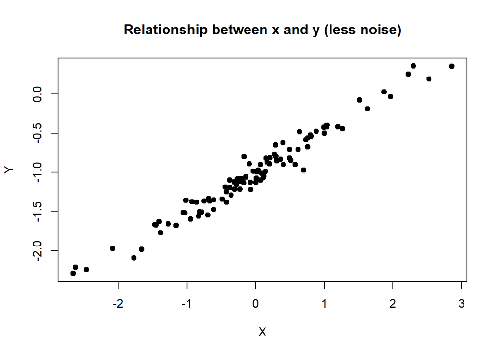

```r
plot(x, y, main="Relationship between x and y (less noise)",
   xlab="X", ylab="Y", pch=19)
```

```r
df <- data.frame(x,y)

model <- lm(y~x, data = df)
print(summary(model))
```

```
##
## Call:
## lm(formula = y ~ x, data = df)
##
## Residuals:
##      Min       1Q   Median       3Q      Max
## -0.32443 -0.07418  0.01032  0.06776  0.28781
##
## Coefficients:
##              Estimate Std. Error t value Pr(>|t|)
## (Intercept) -1.004521   0.010236  -98.14   <2e-16 ***
## x            0.513513   0.009972   51.49   <2e-16 ***
## ---
## Signif. codes:  0 '***' 0.001 '**' 0.01 '*' 0.05 '.' 0.1 ' ' 1
##
## Residual standard error: 0.1023 on 98 degrees of freedom
## Multiple R-squared:  0.9644, Adjusted R-squared:  0.964
## F-statistic:  2652 on 1 and 98 DF,  p-value: < 2.2e-16
```

```r
model <- lm(y ~ poly(x,2), data = df)
print(summary(model))
```

```
##
## Call:
## lm(formula = y ~ poly(x, 2), data = df)
##
## Residuals:
##      Min       1Q   Median       3Q      Max
## -0.32085 -0.07413  0.01198  0.06567  0.29387
##
## Coefficients:
##             Estimate Std. Error t value Pr(>|t|)
## (Intercept) -1.02283    0.01023 -99.993   <2e-16 ***
## poly(x, 2)1  5.26784    0.10229  51.499   <2e-16 ***
## poly(x, 2)2  0.10315    0.10229   1.008    0.316
## ---
## Signif. codes:  0 '***' 0.001 '**' 0.01 '*' 0.05 '.' 0.1 ' ' 1
##
## Residual standard error: 0.1023 on 97 degrees of freedom
## Multiple R-squared:  0.9647, Adjusted R-squared:  0.964
## F-statistic:  1327 on 2 and 97 DF,  p-value: < 2.2e-16
```